## Anàlisi descriptiva abans del preprocessing

En aquesta secció es fa una anàlisi descriptiva (univariant i bivariant) de les dades crues abans del preprocessing.

### Anàlisi univariant de les variables

**Variables categòriques**

Pel que fa a l’anàlisi descriptiva univariant per a variables categòriques, es creen gràfiques de tipus *pie chart* que representen la part proporcional de cada nivell o categoria sobre el total d’observacions de la variable categòrica així com un gràfic de barres que compta les ocurrències de cada categoria o nivell de la variable. La mateixa informació que mostren aquests dos gràfics es pot representar en una taula de freqüències.

*COURSE*

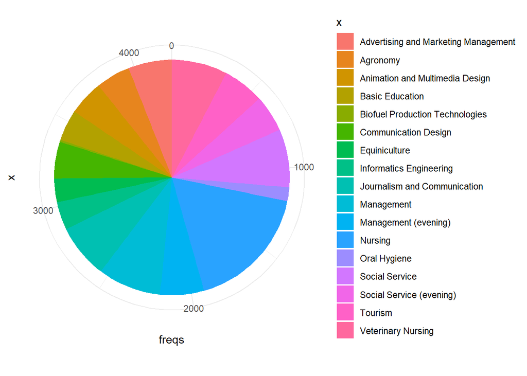

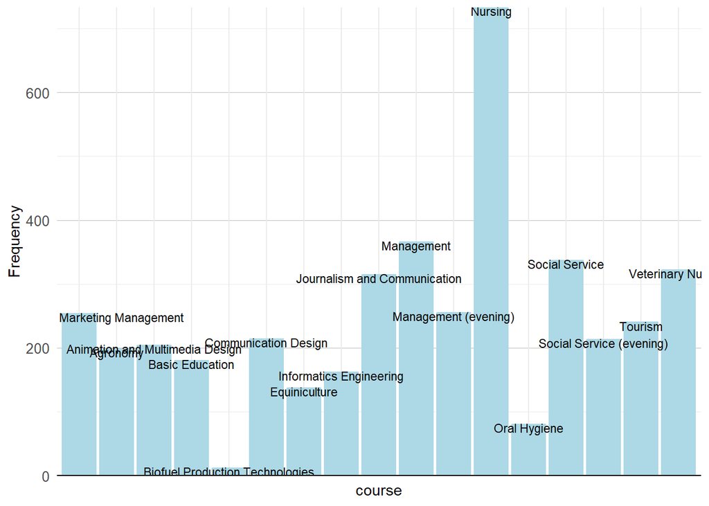

```
##
## --------------------------------------------------------------------------
## Variable   Stats / Values                   Freqs (% of Valid)   Missing
## ---------- -------------------------------- -------------------- ---------
## course\    1\. Biofuel Production Techno\   12 ( 0.3%)\          202\
## [factor]   2\. Animation and Multimedia \   204 ( 4.8%)\         (4.6%)
##            3\. Social Service (evening)\    213 ( 5.0%)\
##            4\. Agronomy\                    198 ( 4.7%)\
##            5\. Communication Design\        214 ( 5.1%)\
##            6\. Veterinary Nursing\          322 ( 7.6%)\
##            7\. Informatics Engineering\     162 ( 3.8%)\
##            8\. Equiniculture\               137 ( 3.2%)\
##            9\. Management\                  366 ( 8.7%)\
##            10\. Social Service\             337 ( 8.0%)\
##            [ 7 others ]                     2057 (48.7%)
## --------------------------------------------------------------------------
```

El curs amb menys estudiants és el de “Biofuel Production Techno” amb un total de 12 alumnes. Així mateix, el curs amb més estudiants és el de “Nursing”.

*DAYTIME_ATTENDANCE*

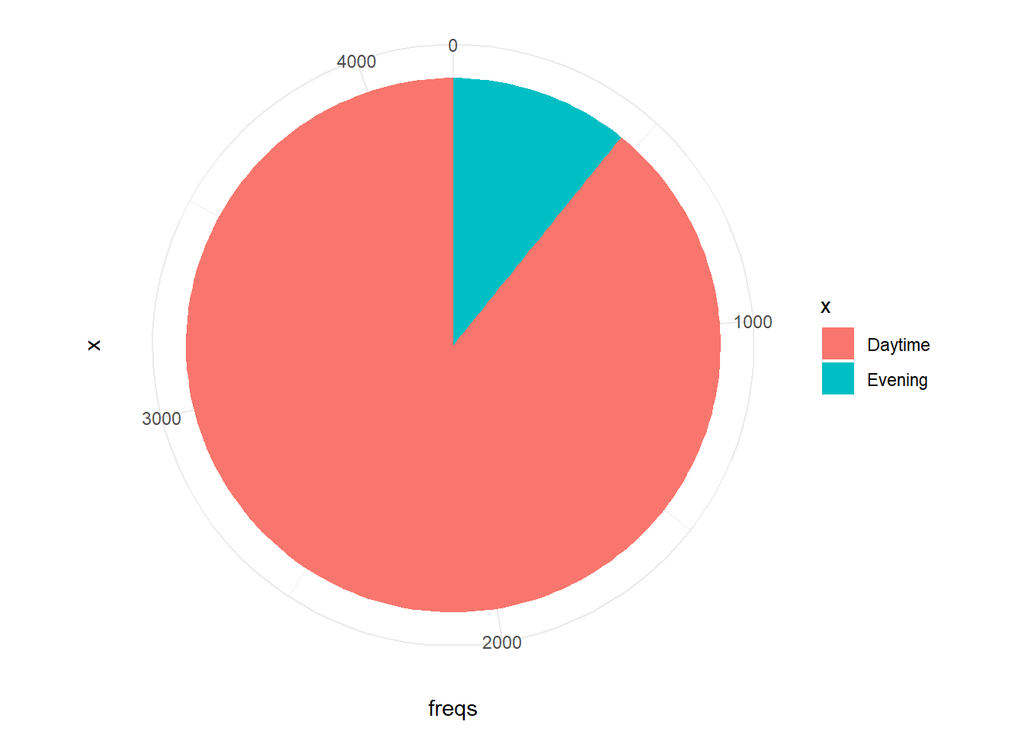

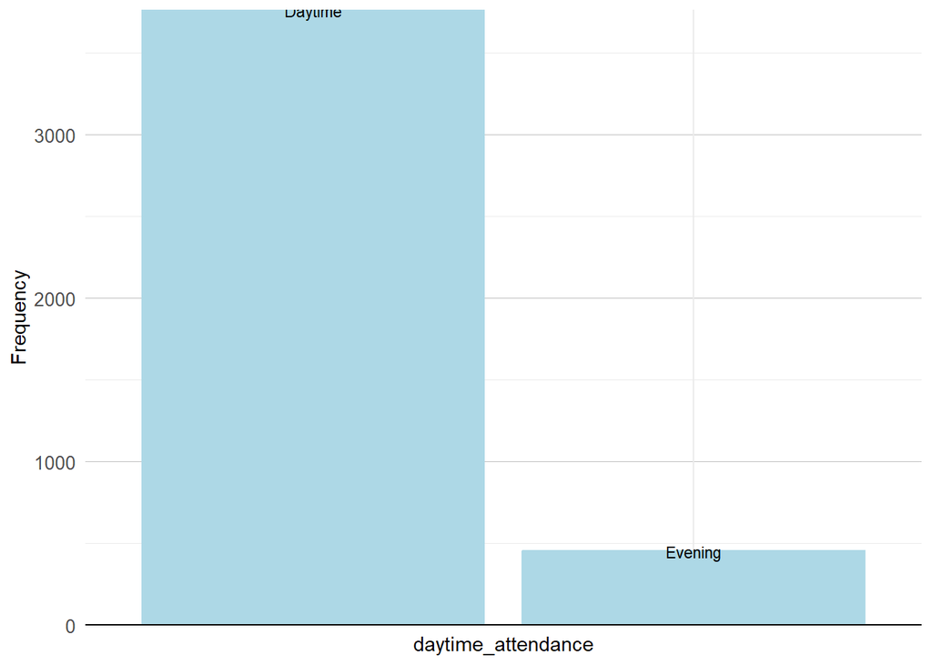

```
##
## ---------------------------------------------------------------------
## Variable              Stats / Values   Freqs (% of Valid)   Missing
## --------------------- ---------------- -------------------- ---------
## daytime_attendance\   1\. Evening\     456 (10.8%)\         205\
## [factor]              2\. Daytime      3763 (89.2%)         (4.6%)
## ---------------------------------------------------------------------
```

La major part de l’assistència es concentra en la franja horària del matí.

*NATIONALITY*

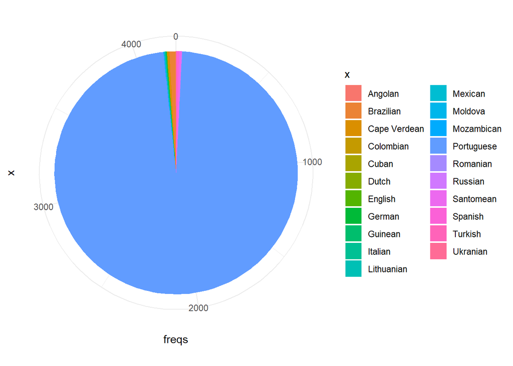

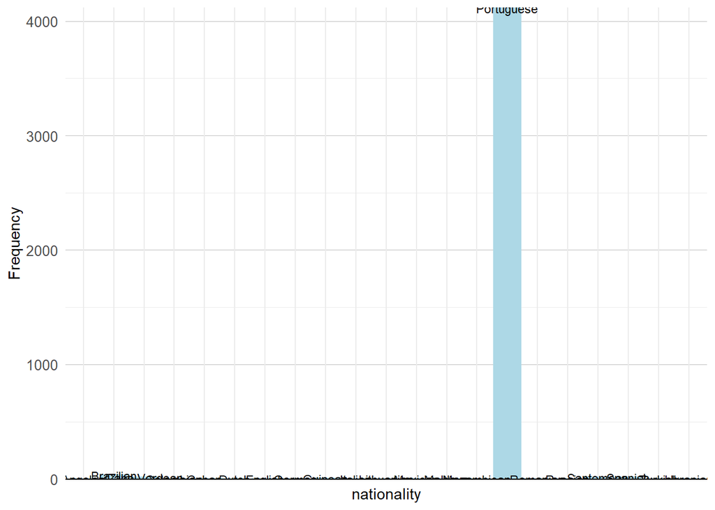

```
##
## -----------------------------------------------------------------
## Variable       Stats / Values      Freqs (% of Valid)   Missing
## -------------- ------------------- -------------------- ---------
## nationality\   1\. Portuguese\     4119 (97.5%)\        200\
## [factor]       2\. German\         2 ( 0.0%)\           (4.5%)
##                3\. Spanish\        13 ( 0.3%)\
##                4\. Italian\        3 ( 0.1%)\
##                5\. Dutch\          1 ( 0.0%)\
##                6\. English\        1 ( 0.0%)\
##                7\. Lithuanian\     1 ( 0.0%)\
##                8\. Angolan\        2 ( 0.0%)\
##                9\. Cape Verdean\   13 ( 0.3%)\
##                10\. Guinean\       5 ( 0.1%)\
##                [ 11 others ]       64 ( 1.5%)
## -----------------------------------------------------------------
```

El 97.5% dels alumnes són portuguesos. Les altres 20 nacionalitats es distribueixen entre el 2.5% restant dels individus.

*OCCUPATION_MOTHER*

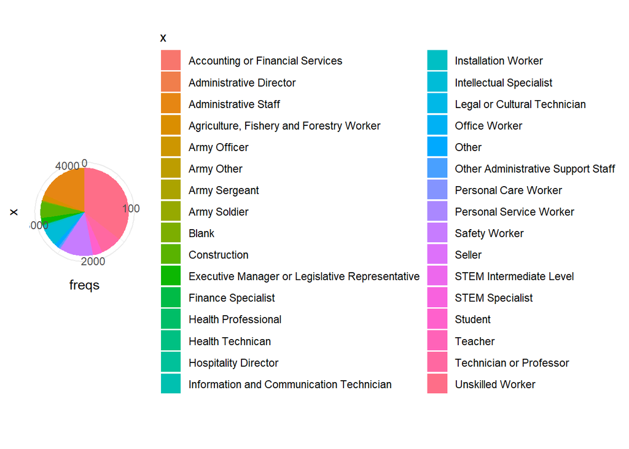

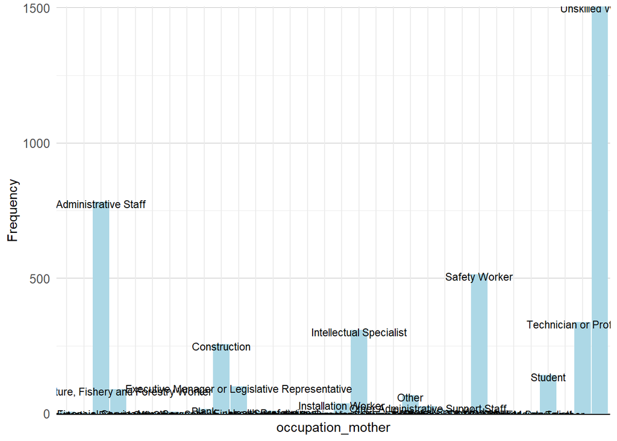

```
##
## ------------------------------------------------------------------------------------
## Variable             Stats / Values                   Freqs (% of Valid)   Missing
## -------------------- -------------------------------- -------------------- ---------
## occupation_mother\   1\. Student\                     140 ( 3.3%)\         190\
## [factor]             2\. Executive Manager or Legi\   99 ( 2.3%)\          (4.3%)
##                      3\. Intellectual Specialist\     307 ( 7.3%)\
##                      4\. Technician or Professor\     336 ( 7.9%)\
##                      5\. Administrative Staff\        781 (18.4%)\
##                      6\. Safety Worker\               513 (12.1%)\
##                      7\. Agriculture, Fishery and \   88 ( 2.1%)\
##                      8\. Construction\                254 ( 6.0%)\
##                      9\. Installation Worker\         36 ( 0.9%)\
##                      10\. Unskilled Worker\           1504 (35.5%)\
##                      [ 22 others ]                    176 ( 4.2%)
## ------------------------------------------------------------------------------------
```

Les ocupacions de les mares més destacades són treballadora no qualificada (35.5%) i personal administratiu (18.4%).

*OCCUPATION_FATHER*

[figure not shown]

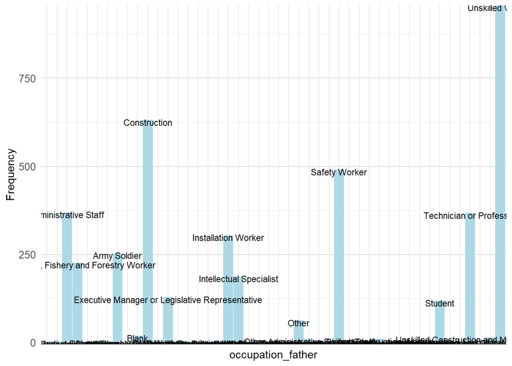

```
##
## ------------------------------------------------------------------------------------
## Variable             Stats / Values                   Freqs (% of Valid)   Missing
## -------------------- -------------------------------- -------------------- ---------
## occupation_father\   1\. Student\                     117 ( 2.8%)\         241\
## [factor]             2\. Executive Manager or Legi\   127 ( 3.0%)\         (5.4%)
##                      3\. Intellectual Specialist\     186 ( 4.4%)\
##                      4\. Technician or Professor\     366 ( 8.7%)\
##                      5\. Administrative Staff\        368 ( 8.8%)\
##                      6\. Safety Worker\               489 (11.7%)\
##                      7\. Agriculture, Fishery and \   225 ( 5.4%)\
##                      8\. Construction\                630 (15.1%)\
##                      9\. Installation Worker\         303 ( 7.2%)\
##                      10\. Unskilled Worker\           956 (22.9%)\
##                      [ 36 others ]                    416 ( 9.9%)
## ------------------------------------------------------------------------------------
```

La feina més representativa dels pares és treballador no qualificat, seguida dels llocs de treball a la construcció.

*SPECIAL_NEEDS*

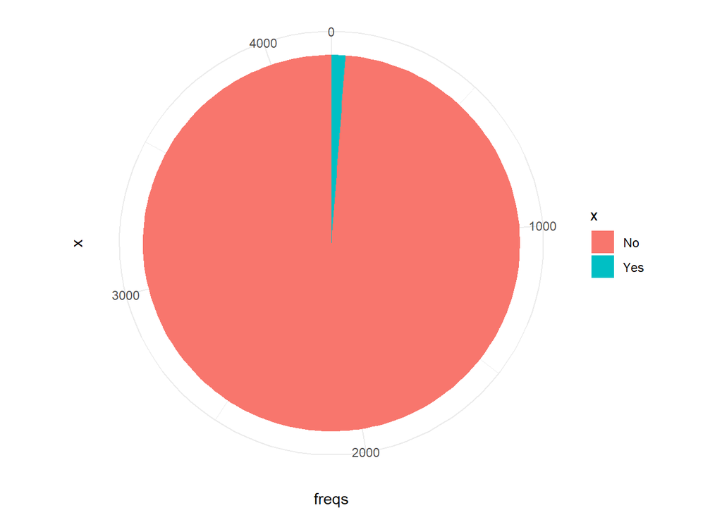

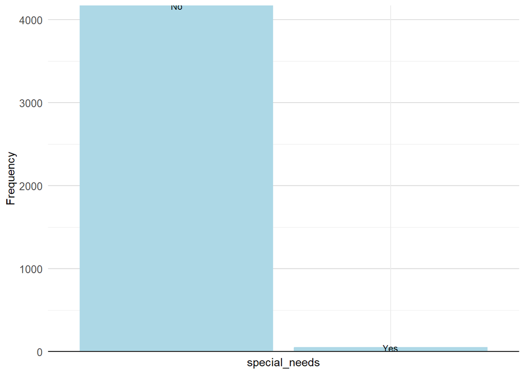

```
##
## ----------------------------------------------------------------
## Variable         Stats / Values   Freqs (% of Valid)   Missing
## ---------------- ---------------- -------------------- ---------
## special_needs\   1\. No\          4170 (98.8%)\        204\
## [factor]         2\. Yes          50 ( 1.2%)           (4.6%)
## ----------------------------------------------------------------
```

*GENDER*

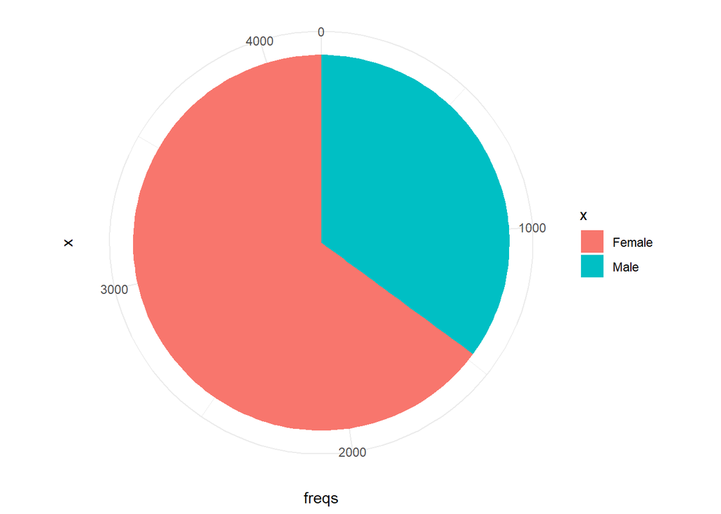

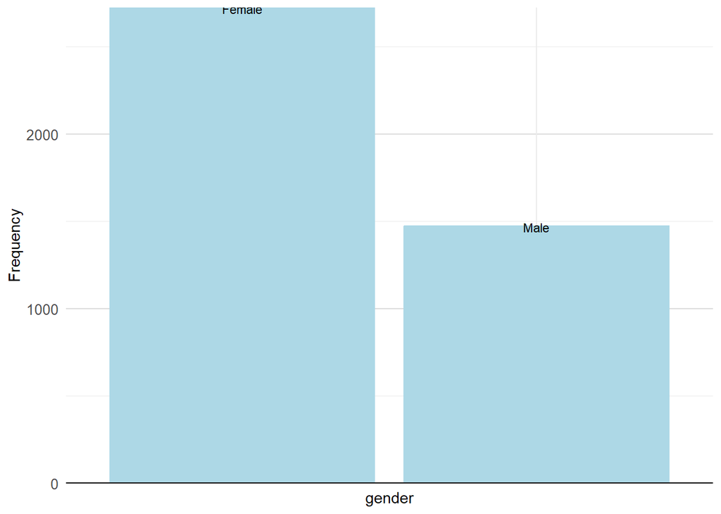

```
##
## ----------------------------------------------------------
## Variable   Stats / Values   Freqs (% of Valid)   Missing
## ---------- ---------------- -------------------- ---------
## gender\    1\. Female\      2724 (64.9%)\        227\
## [factor]   2\. Male         1473 (35.1%)         (5.1%)
## ----------------------------------------------------------
```

Aproximadament el 65% dels individus s’identifiquen com a dona.

*SCHOLARSHIP*

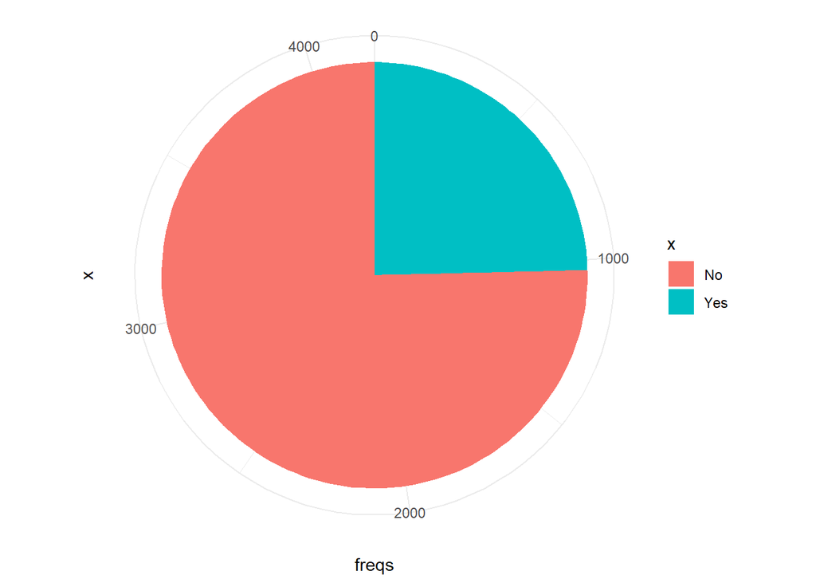

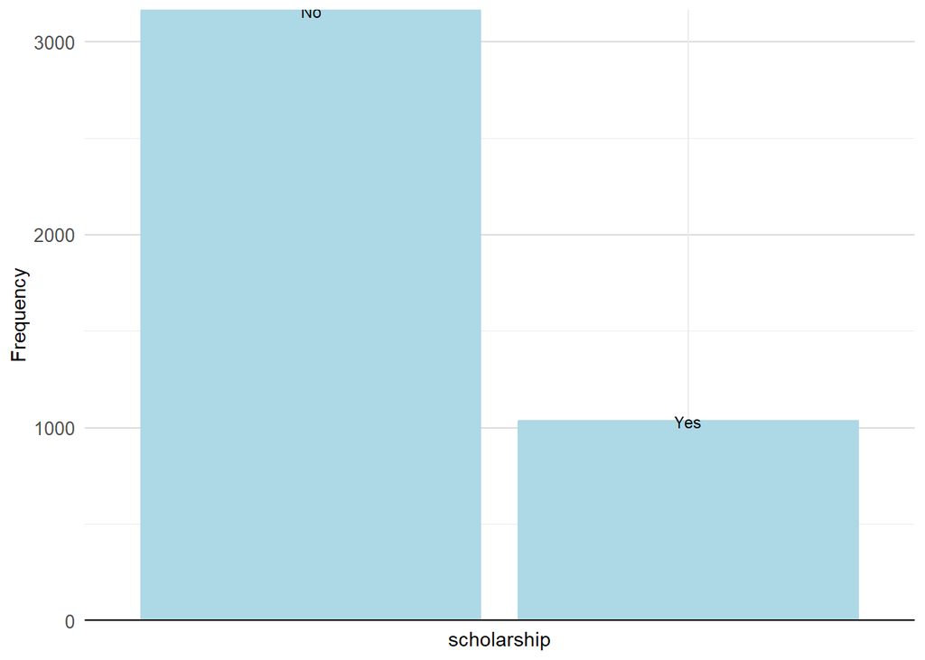

```
##
## --------------------------------------------------------------
## Variable       Stats / Values   Freqs (% of Valid)   Missing
## -------------- ---------------- -------------------- ---------
## scholarship\   1\. No\          3164 (75.4%)\        226\
## [factor]       2\. Yes          1034 (24.6%)         (5.1%)
## --------------------------------------------------------------
```

Tres quartes parts dels alumnes no reben cap mena d’ajuda econòmica.

*TARGET*

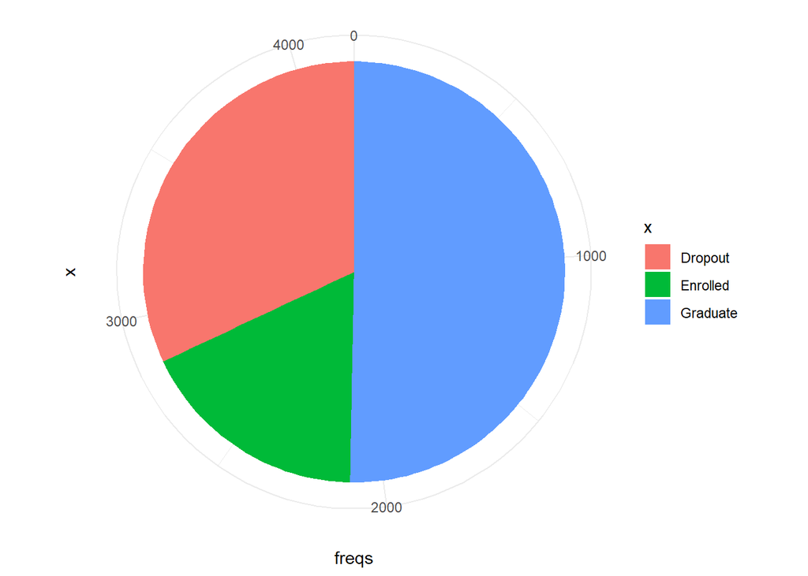

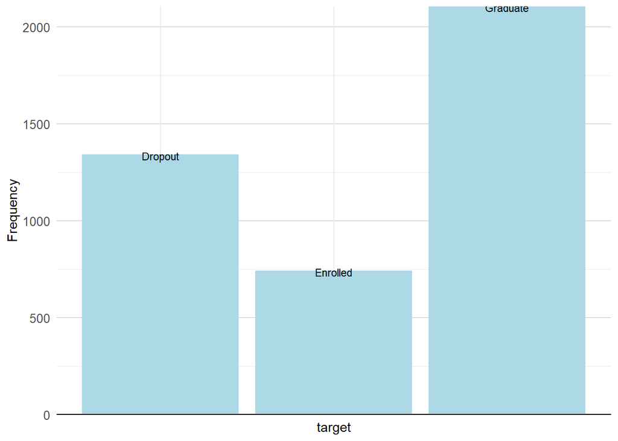

```
##
## ----------------------------------------------------------
## Variable   Stats / Values   Freqs (% of Valid)   Missing
## ---------- ---------------- -------------------- ---------
## target\    1\. Dropout\     1339 (32.0%)\        239\
## [factor]   2\. Enrolled\    741 (17.7%)\         (5.4%)
##            3\. Graduate     2105 (50.3%)
## ----------------------------------------------------------
```

La meitat dels enquestats són graduats, el 32% ha abandonat els estudis i quasi el 18% són persones que han reprès els estudis.

*PREVIOUS_QUALIFICATION*

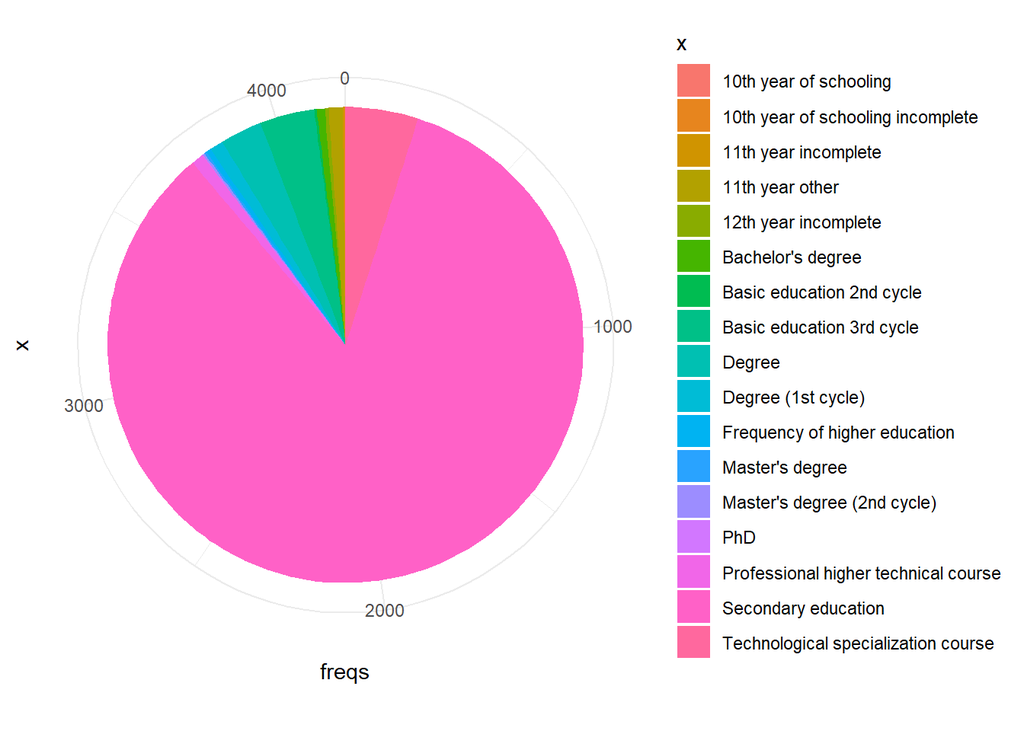

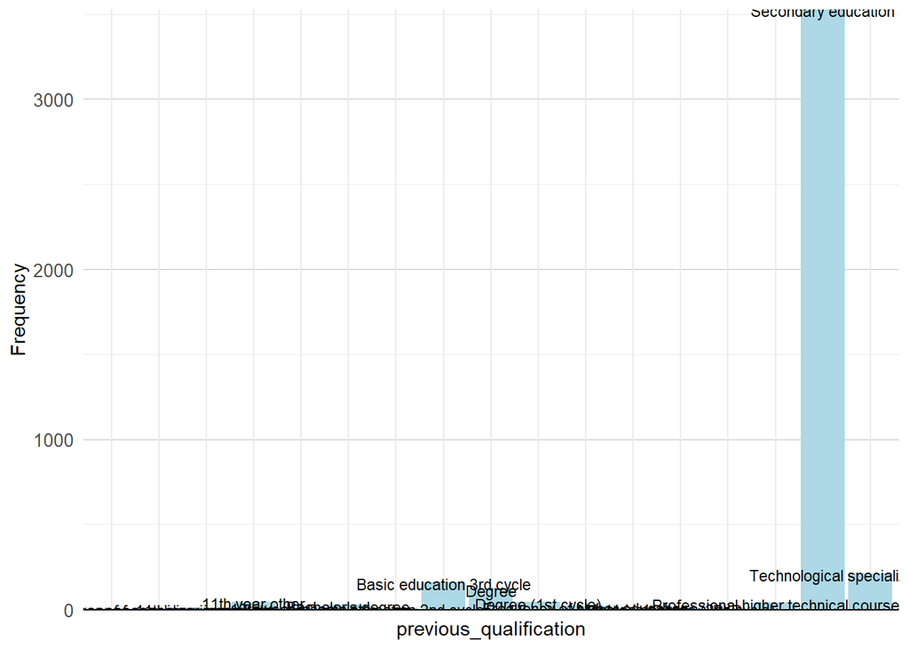

```
##
## -----------------------------------------------------------------------------------------
## Variable                  Stats / Values                   Freqs (% of Valid)   Missing
## ------------------------- -------------------------------- -------------------- ---------
## previous_qualification\   1\. Secondary education\         3526 (84.0%)\        225\
## [factor]                  2\. Bachelor's degree\           23 ( 0.5%)\          (5.1%)
##                           3\. Degree\                      119 ( 2.8%)\
##                           4\. Master's degree\             6 ( 0.1%)\
##                           5\. PhD\                         1 ( 0.0%)\
##                           6\. Frequency of higher educa\   15 ( 0.4%)\
##                           7\. 12th year incomplete\        11 ( 0.3%)\
##                           8\. 11th year incomplete\        4 ( 0.1%)\
##                           9\. 11th year other\             41 ( 1.0%)\
##                           10\. 10th year of schooling\     1 ( 0.0%)\
##                           [ 7 others ]                     452 (10.8%)
## -----------------------------------------------------------------------------------------
```

El 84% dels estudiants tenen l’Educació Secundària Obligatòria.

**Variables numèriques**

Per a l’anàlisi univariant de variables numèriques s’utilitza un histograma per analitzar visualment els valors que pren aquesta variable. També es fa un resum (i.e. *summary*) de la variable que permet conèixer, entre altres coses, quina és la mitjana, la mediana, el valor màxim i el valor mínim que pren.

*AGE*

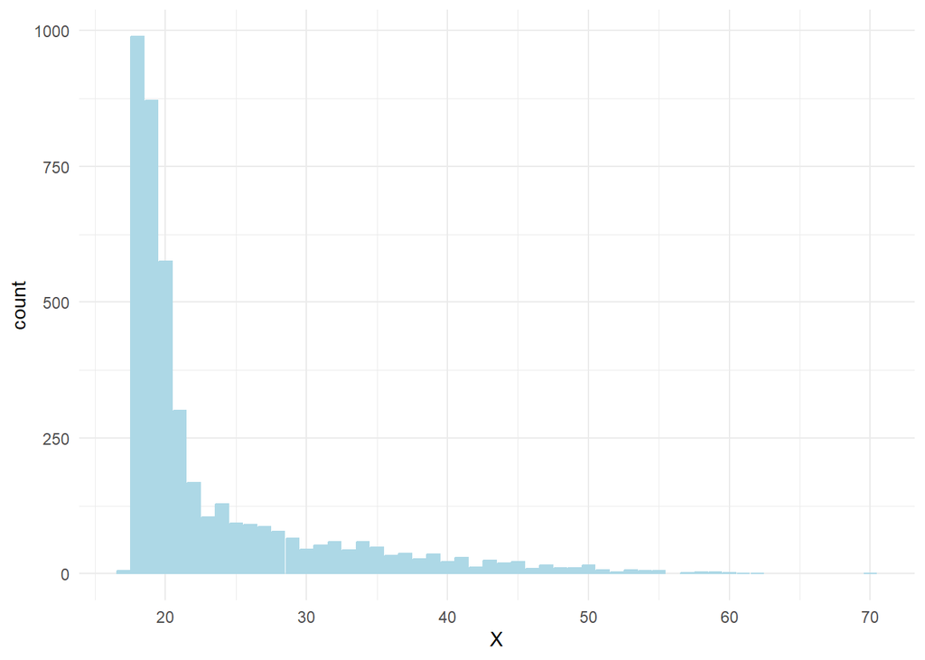

```
##
## | N.Valid  |  Min   |   Q1   | Median |  Mean  | Std.Dev |   Q3   |  Max   |  IQR  |
## |:--------:|:------:|:------:|:------:|:------:|:-------:|:------:|:------:|:-----:|
## | 4226.000 | 17.000 | 19.000 | 20.000 | 23.245 |  7.555  | 25.000 | 70.000 | 6.000 |
```

La variable edat es comprèn dins un interval que va dels 17 als 70 anys amb ambdós inclosos. No obstant això, la població es distribueix principalment al voltant dels 20 anys.

*GRADES_SEM_1*

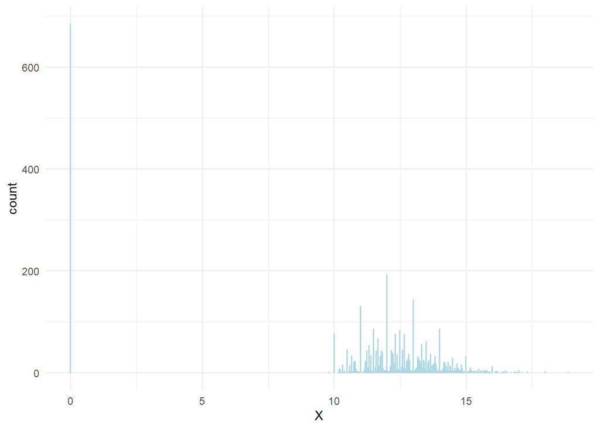

```
##
## | N.Valid  |  Min  |   Q1   | Median |  Mean  | Std.Dev |   Q3   |  Max   |  IQR  |
## |:--------:|:-----:|:------:|:------:|:------:|:-------:|:------:|:------:|:-----:|
## | 4225.000 | 0.000 | 11.000 | 12.290 | 10.645 |  4.842  | 13.400 | 18.880 | 2.400 |
```

Les notes del primer semestre es reparteix en gran manera entre 10 i 14.

*NO_EVAL_SEM_1*

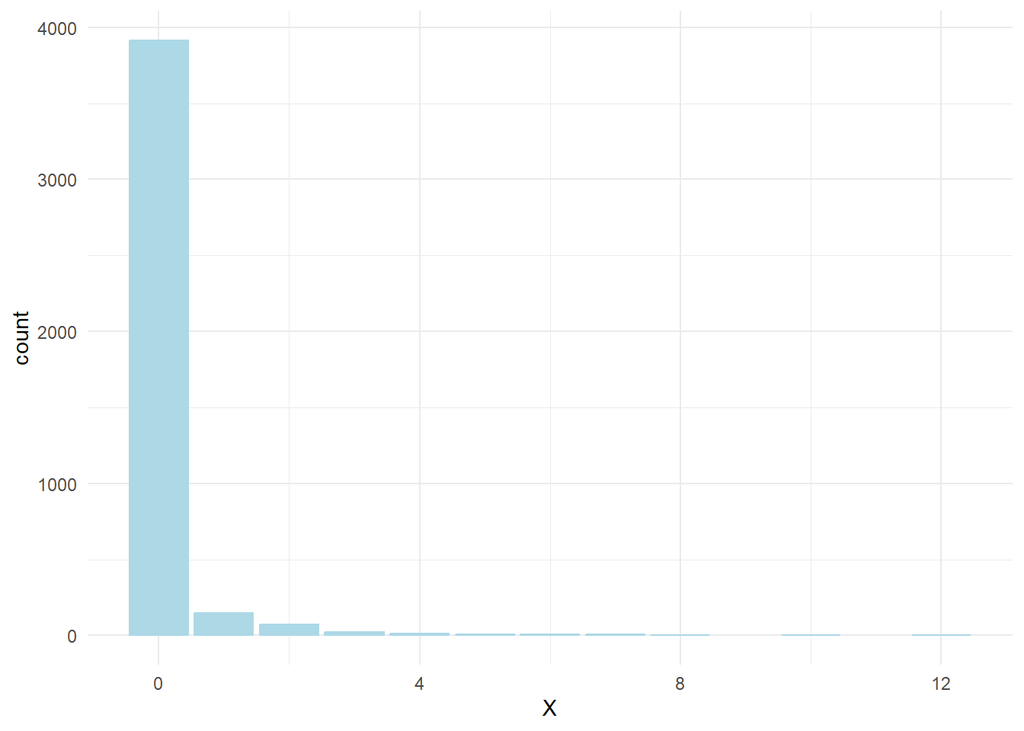

```
##
## | N.Valid  |  Min  |  Q1   | Median | Mean  | Std.Dev |  Q3   |  Max   |  IQR  |
## |:--------:|:-----:|:-----:|:------:|:-----:|:-------:|:-----:|:------:|:-----:|
## | 4191.000 | 0.000 | 0.000 | 0.000  | 0.136 |  0.686  | 0.000 | 12.000 | 0.000 |
```

Majoritàriament, no hi ha unitats curriculars no avaluades el primer semestre.

*GRADES_SEM_2*

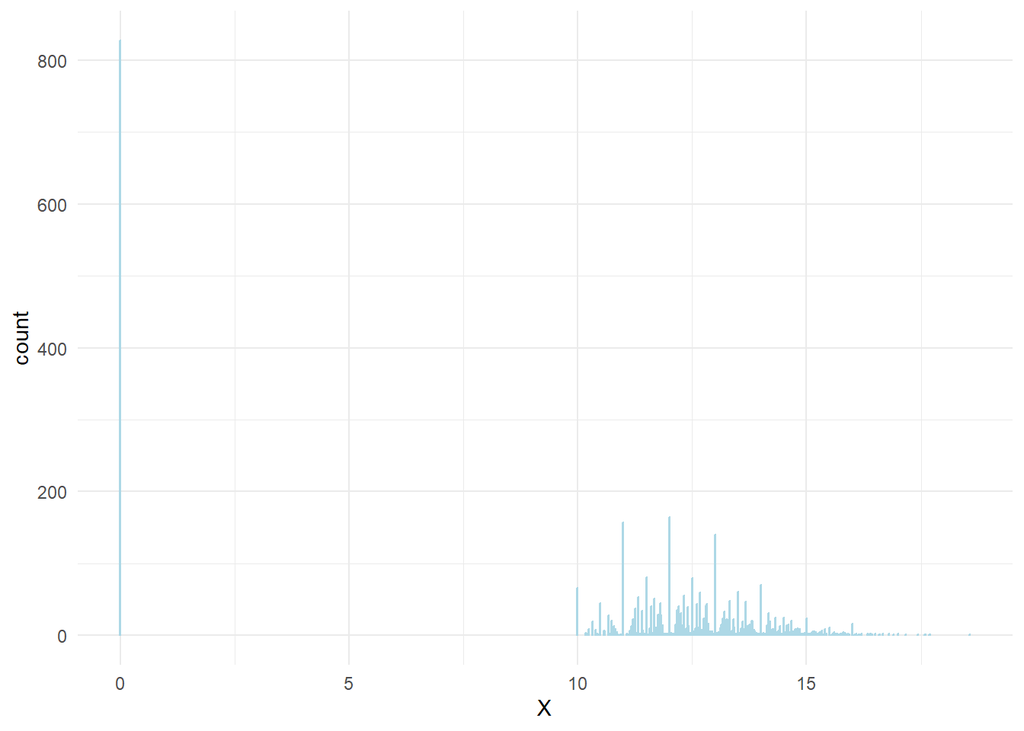

```
##
## | N.Valid  |  Min  |   Q1   | Median |  Mean  | Std.Dev |   Q3   |  Max   |  IQR  |
## |:--------:|:-----:|:------:|:------:|:------:|:-------:|:------:|:------:|:-----:|
## | 4179.000 | 0.000 | 10.750 | 12.210 | 10.219 |  5.223  | 13.330 | 18.570 | 2.580 |
```

Les notes del segon semestre es reparteix en gran manera entre 10 i 14.

*NO_EVAL_SEM_2*

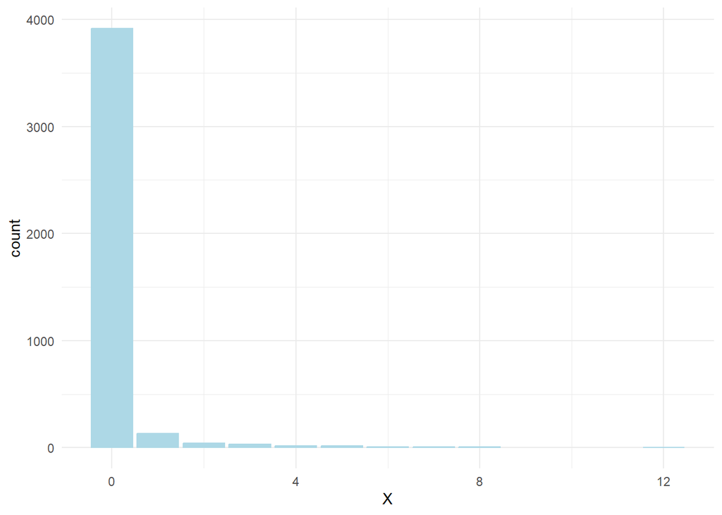

```
##
## | N.Valid  |  Min  |  Q1   | Median | Mean  | Std.Dev |  Q3   |  Max   |  IQR  |
## |:--------:|:-----:|:-----:|:------:|:-----:|:-------:|:-----:|:------:|:-----:|
## | 4179.000 | 0.000 | 0.000 | 0.000  | 0.148 |  0.747  | 0.000 | 12.000 | 0.000 |
```

Majoritàriament, no hi ha unitats no avaluades el segon semestre.

*UNEMPLOYMENT_RATE*

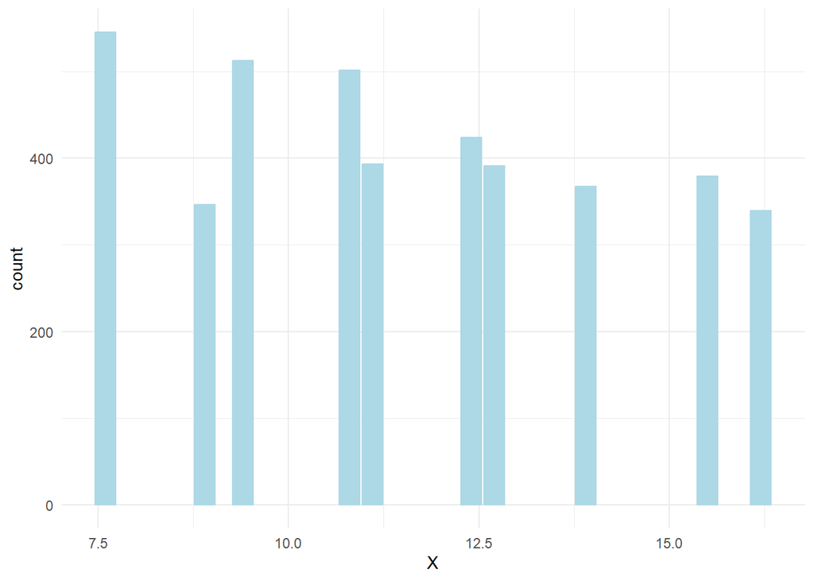

```
##
## | N.Valid  |  Min  |  Q1   | Median |  Mean  | Std.Dev |   Q3   |  Max   |  IQR  |
## |:--------:|:-----:|:-----:|:------:|:------:|:-------:|:------:|:------:|:-----:|
## | 4197.000 | 7.600 | 9.400 | 11.100 | 11.555 |  2.663  | 13.900 | 16.200 | 4.500 |
```

El valor més baix que pren la taxa d’atur és 7.6% i el més alt, 16.2%.

*INFLATION_RATE*

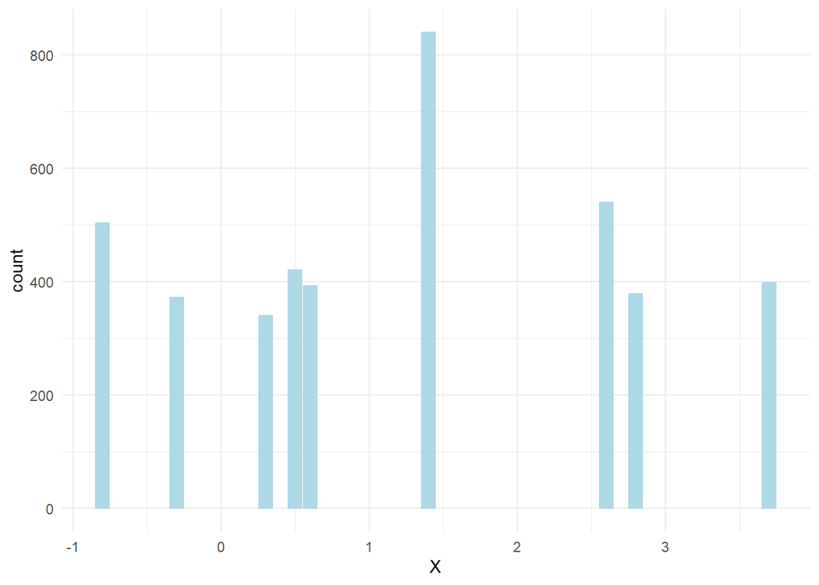

```
##
## | N.Valid  |  Min   |  Q1   | Median | Mean  | Std.Dev |  Q3   |  Max  |  IQR  |
## |:--------:|:------:|:-----:|:------:|:-----:|:-------:|:-----:|:-----:|:-----:|
## | 4187.000 | -0.800 | 0.300 | 1.400  | 1.229 |  1.384  | 2.600 | 3.700 | 2.300 |
```

La màxima taxa d’inflació és del 3.7%.

*GDP*

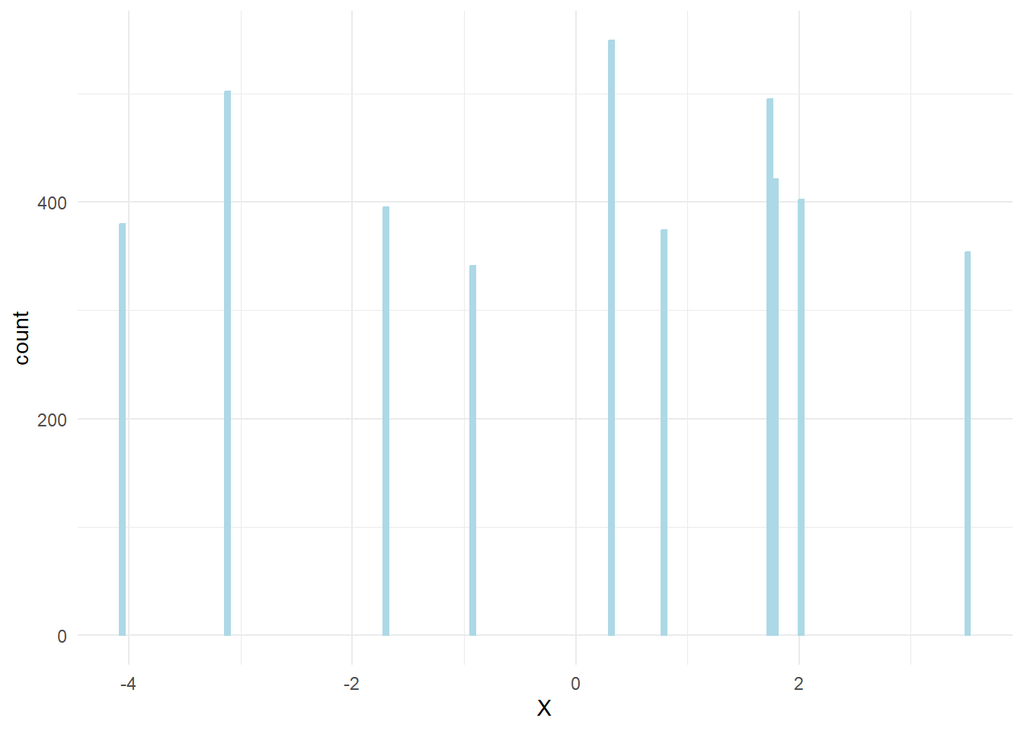

```
##
## | N.Valid  |  Min   |   Q1   | Median | Mean  | Std.Dev |  Q3   |  Max  |  IQR  |
## |:--------:|:------:|:------:|:------:|:-----:|:-------:|:-----:|:-----:|:-----:|
## | 4213.000 | -4.060 | -1.700 | 0.320  | 0.011 |  2.271  | 1.790 | 3.510 | 3.490 |
```

El PIB oscil·la entre -4 i 3.5.

### Anàlisi bivariant

Per a l’anàlisi bivariant es miren les combinacions més interessants (i que més sentit té fer) de dues variables.

**Dues variables numèriques**

A l’hora d’analitzar conjuntament dues variables numèriques, s’utilitza un *scatterplot* on cada variable està representada en un dels dos eixos.

*AGE* i *GRADES_SEM_1*

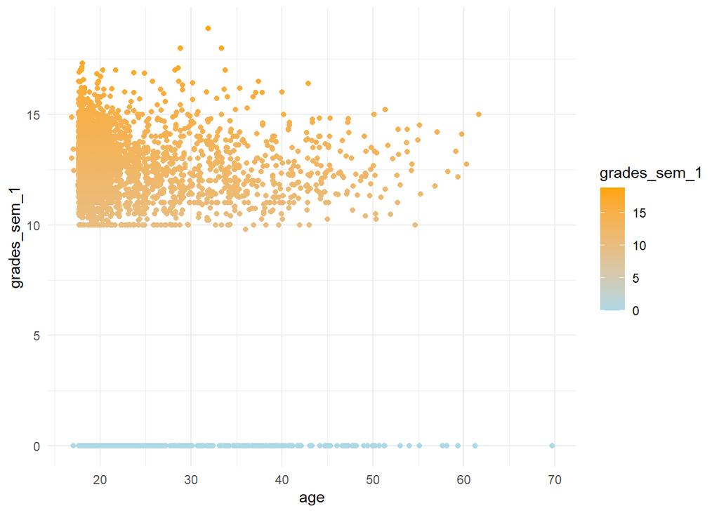

Es veu que no hi ha diferències significatives en la nota del primer semestre segons l’edat. Però en les edats més avançades, les notes poden no arribar a ser tan altes.

*AGE* i *GRADES_SEM_2*

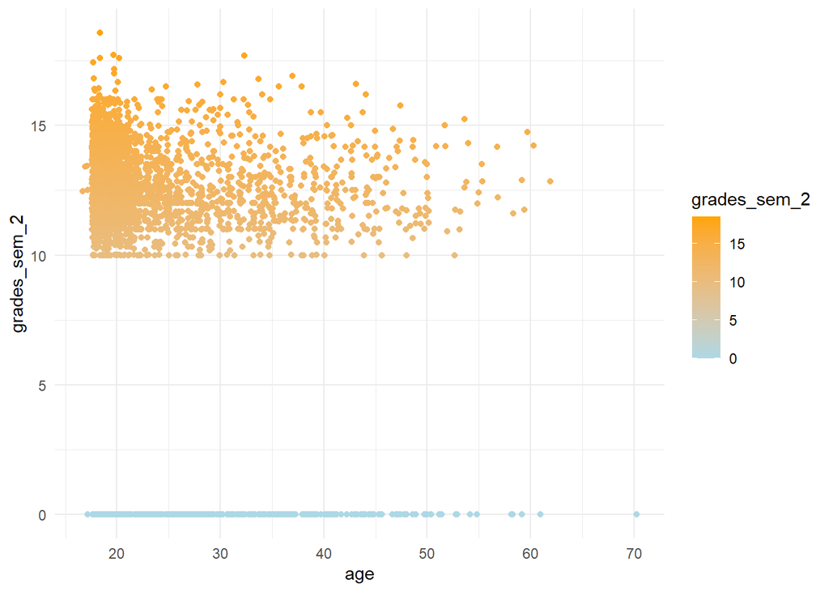

S’observa el mateix que en el gràfic anterior amb les notes del primer semestre.

*AGE* i *NO_EVAL_SEM_1*

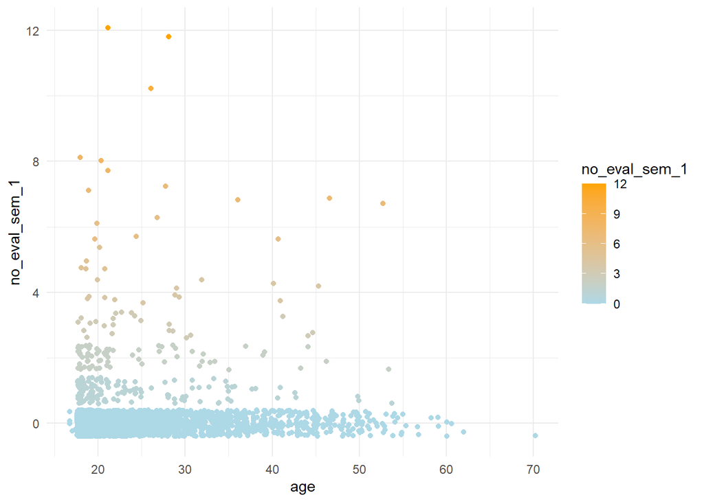

Segons l’edat, no sembla que hi hagi diferències en les unitats no avaluades.